# Income Model

# Marginal Effects Graphs

With so many categorical features it’s difficult to capture the marginal effect of each feature. The sjPlot package was used to graph the marginal effect of each feature. The marginal effects of these numeric features were much easier to visualize. These graphs also show a 95% confidence interval of the marginal effect. The other plots also show a 95% confidence interval of marginal effect of each categorical feature. However, with so many categories they are hard to read. They can still help show the intuition behind which features are important.

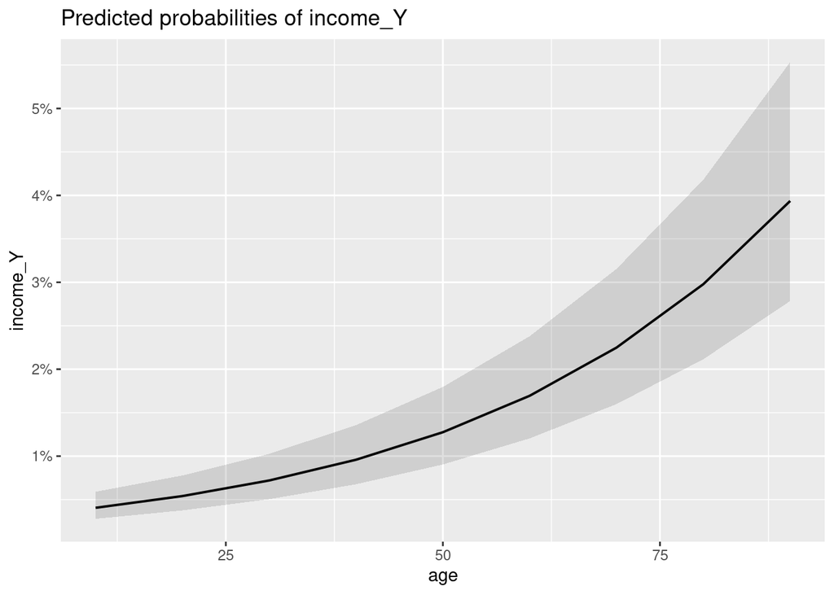

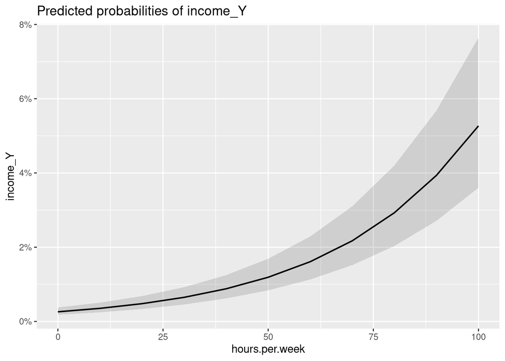

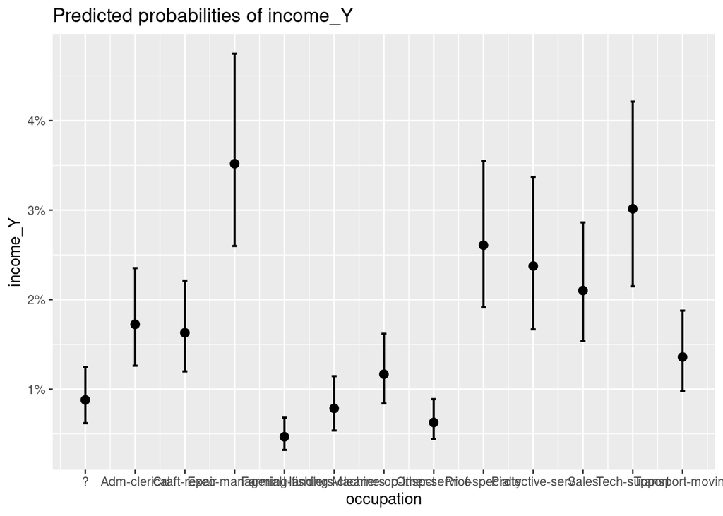

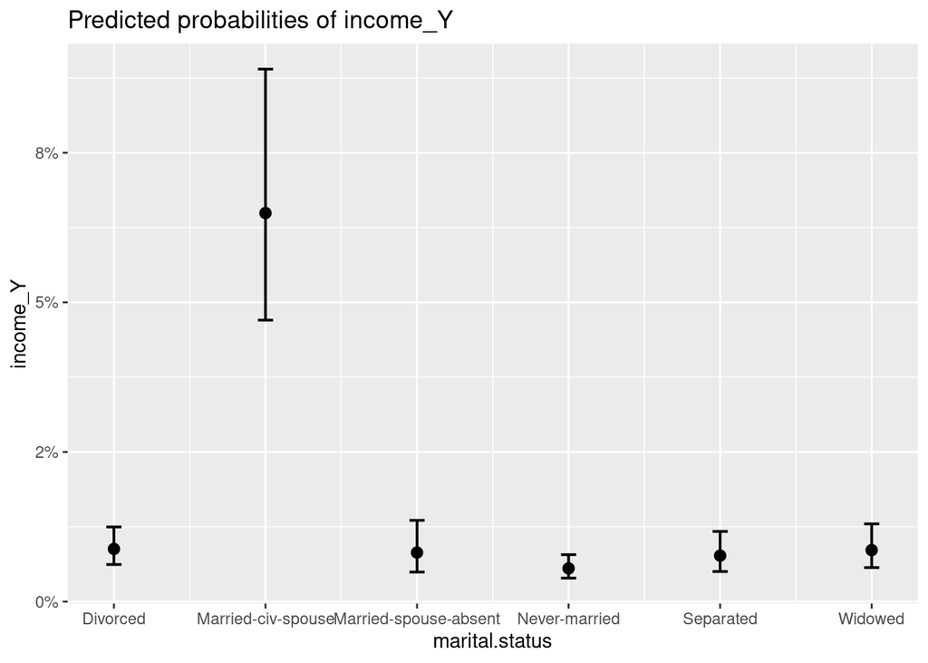

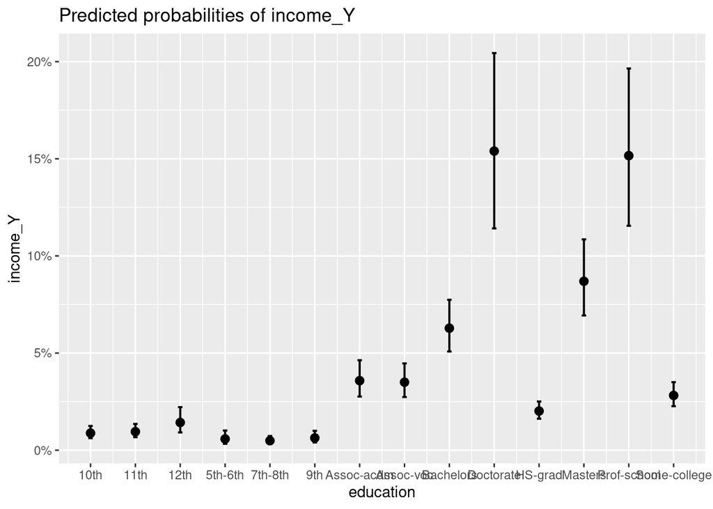

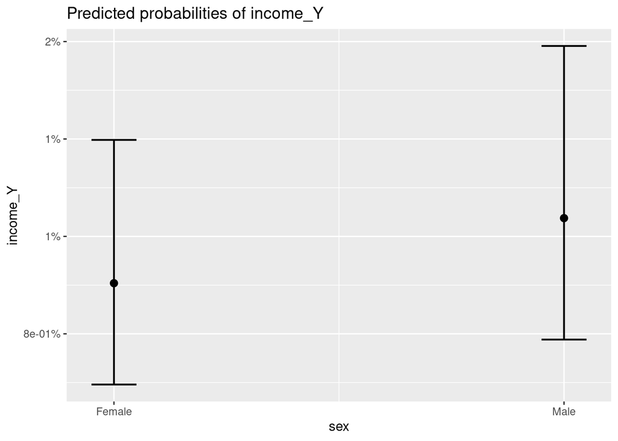